# ePGD-ABA (2020-21) | Finance Elective | Professor Vineet Virmani | Portfolio VaR Assignment

##### The weekly closing prices and returns look like this:

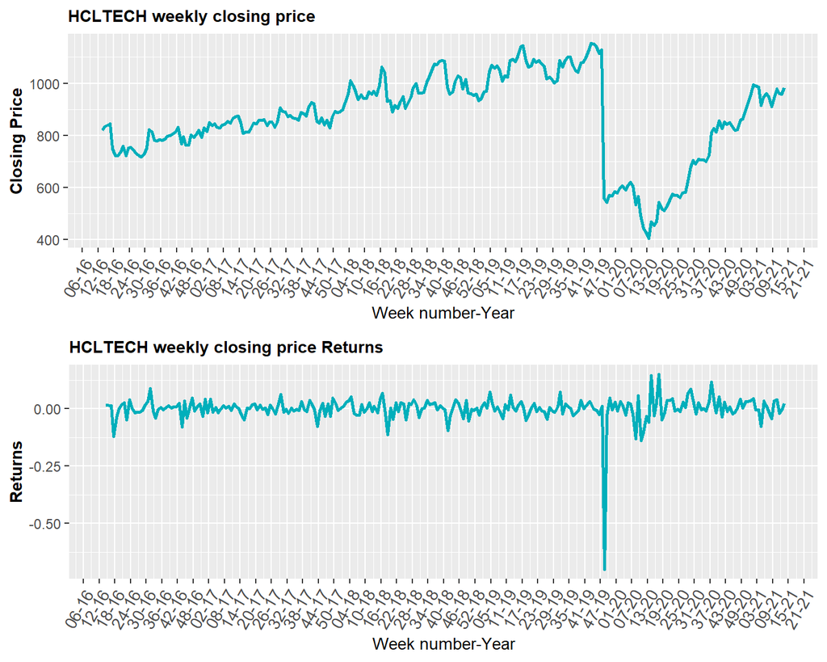

##### The monthly closing prices and returns look like this:

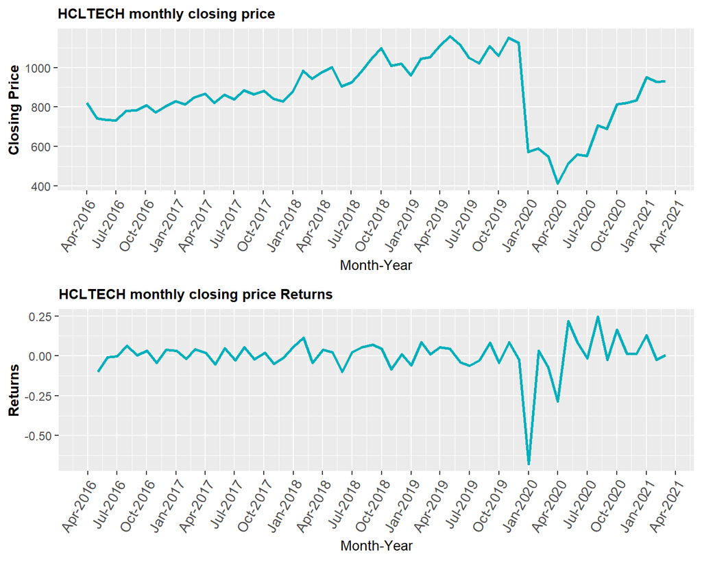

#### HCLTECH daily returns model

##### The **Box-Jenkins** process for daily returns look like this:

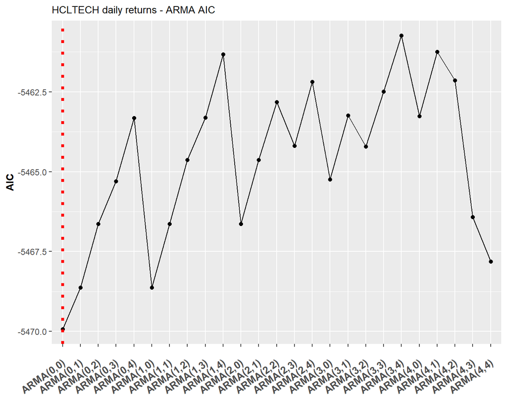

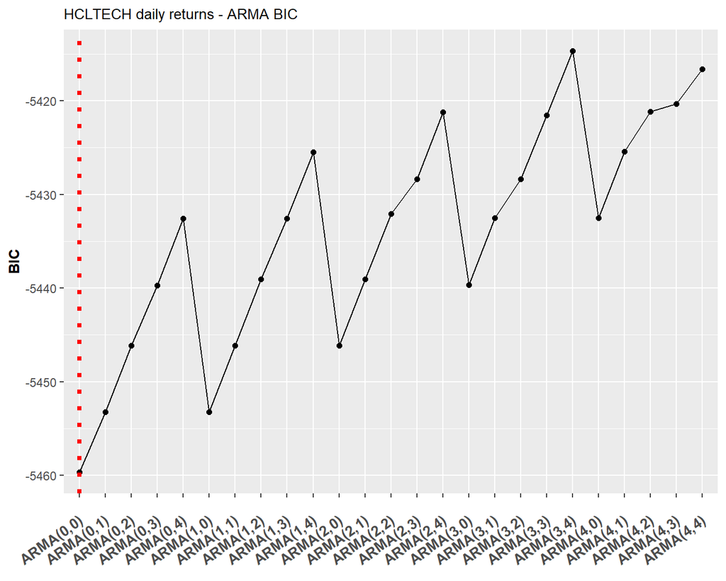

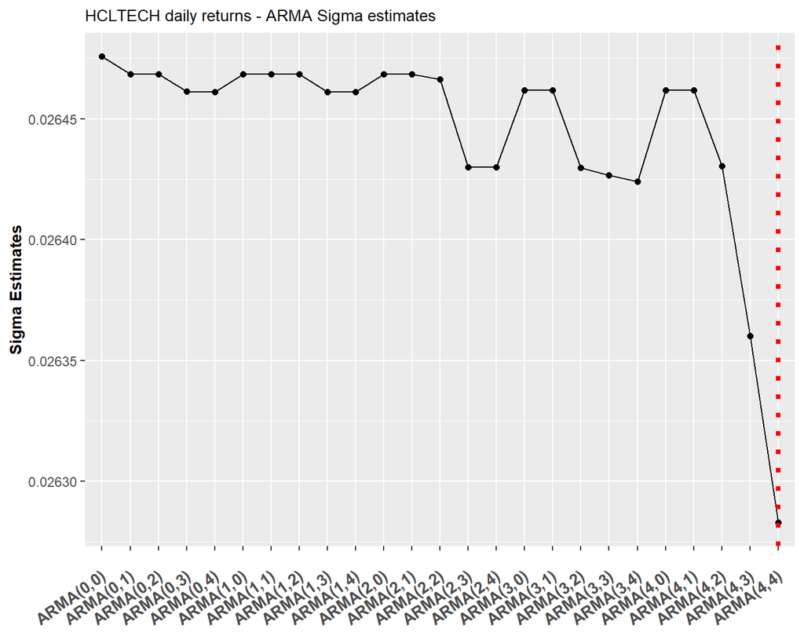

##### The best ARMA model for HCLTECH **daily** returns is **ARMA(0,0)**.

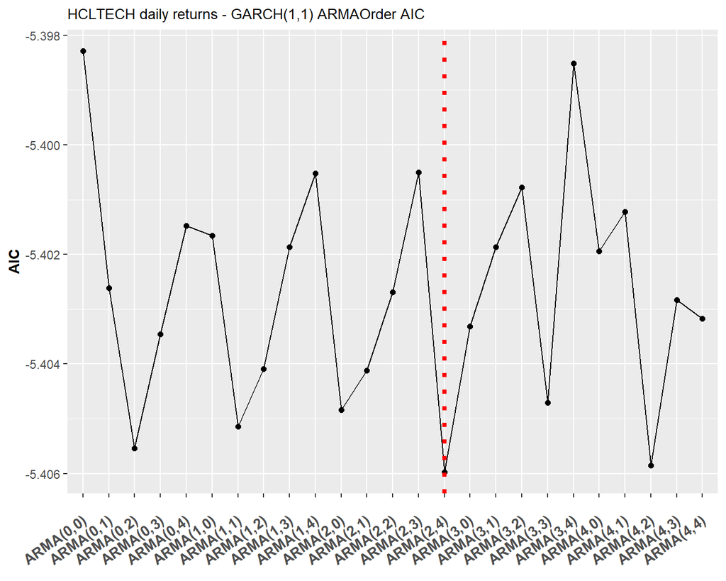

##### The best GARCH model for HCLTECH **daily** returns is **SGARCH(1,1),ARMA(2,4)**.

##### **HCLTECH** **daily** VaR summary:

- HCLTECH daily VaR is **-0.031** at **alpha=5%**
- HCLTECH daily conditional mean is **10^{-4}**
- HCLTECH daily conditional sd is **0.0189**

#### HCLTECH weekly returns model

##### The **Box-Jenkins** process for weekly returns look like this:

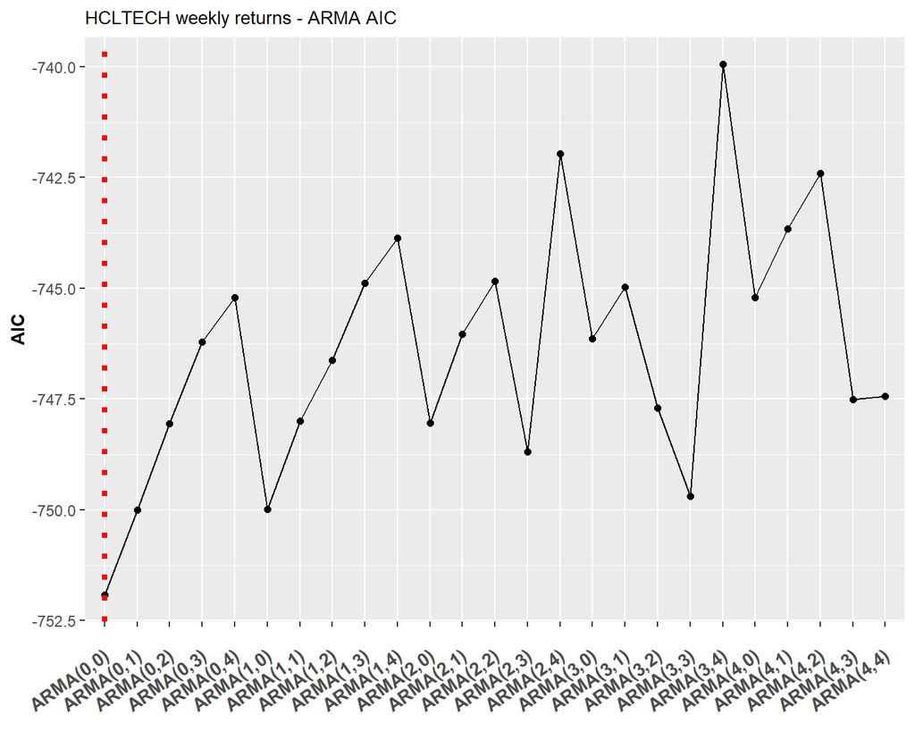

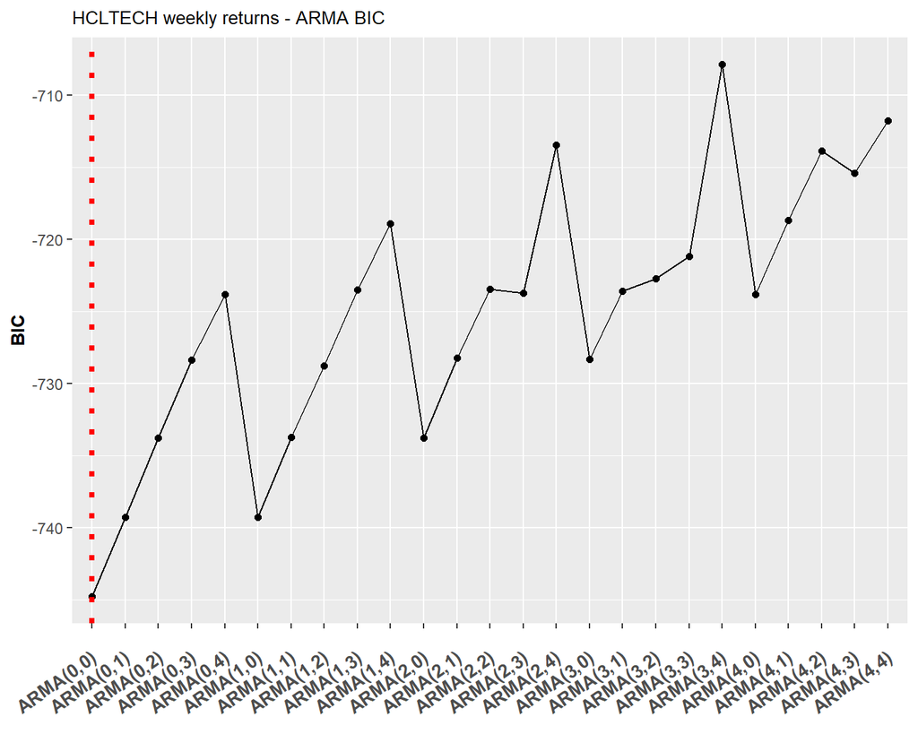

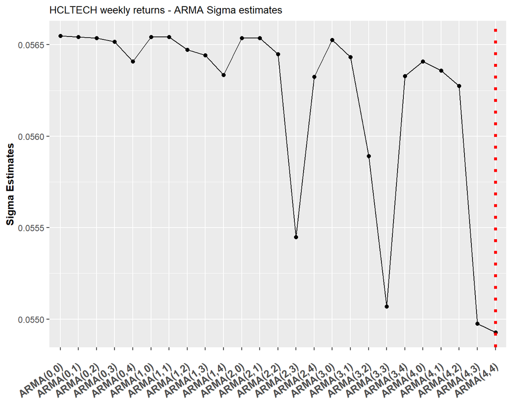

##### The best ARMA model for HCLTECH **weekly** returns is **ARMA(0,0)**.

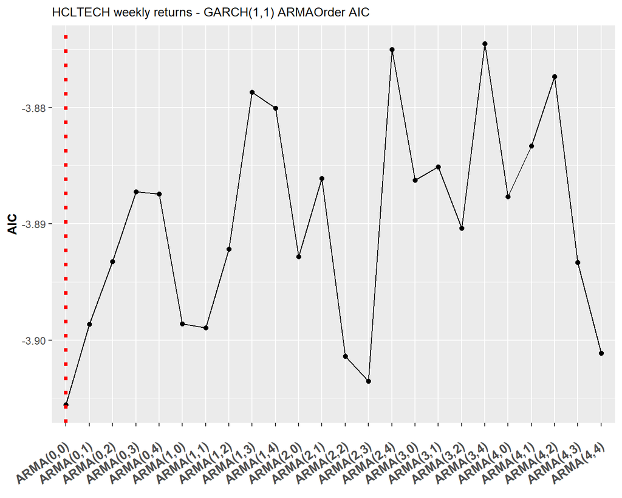

##### The best GARCH model for HCLTECH **weekly** returns is **SGARCH(1,1),ARMA(0,0)**.

##### **HCLTECH** **weekly** VaR summary:

- HCLTECH weekly VaR is **-0.072** at **alpha=5%**
- HCLTECH weekly conditional mean is **7^{-4}**
- HCLTECH weekly conditional sd is **0.0442**

#### HCLTECH monthly returns model

##### The **Box-Jenkins** process for monthly returns look like this:

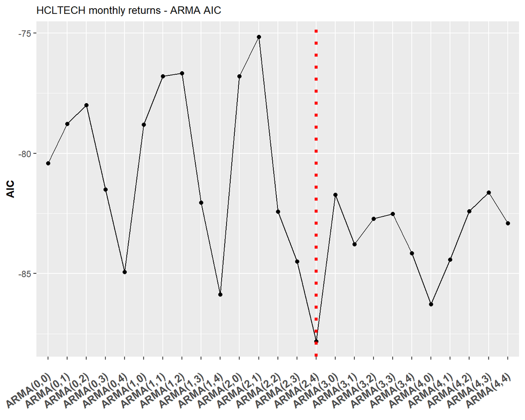

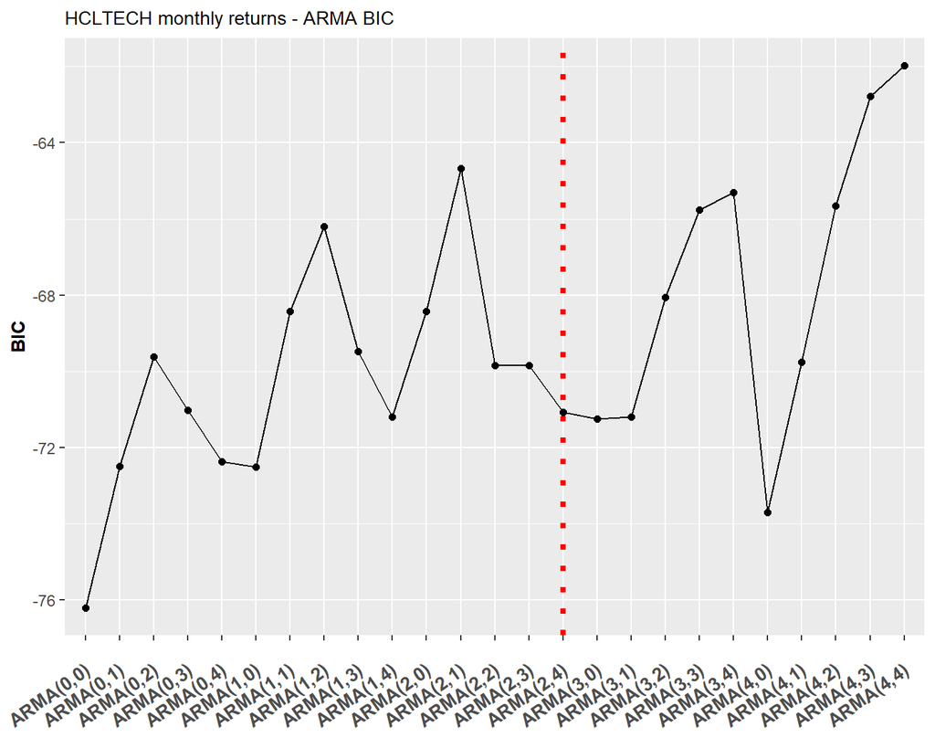

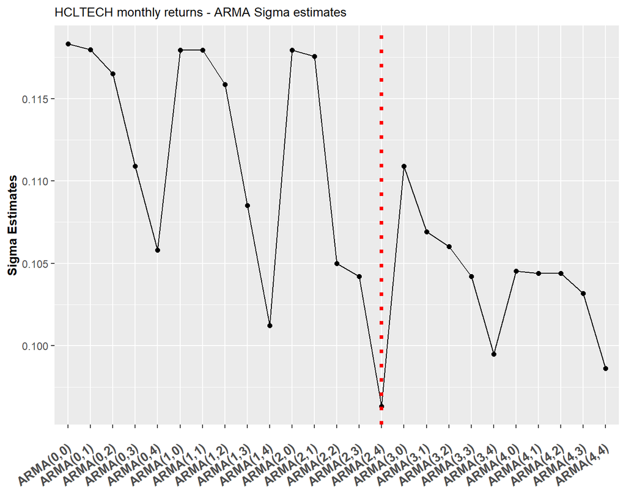

##### The best ARMA model for HCLTECH **monthly** returns is **ARMA(2,4)**.

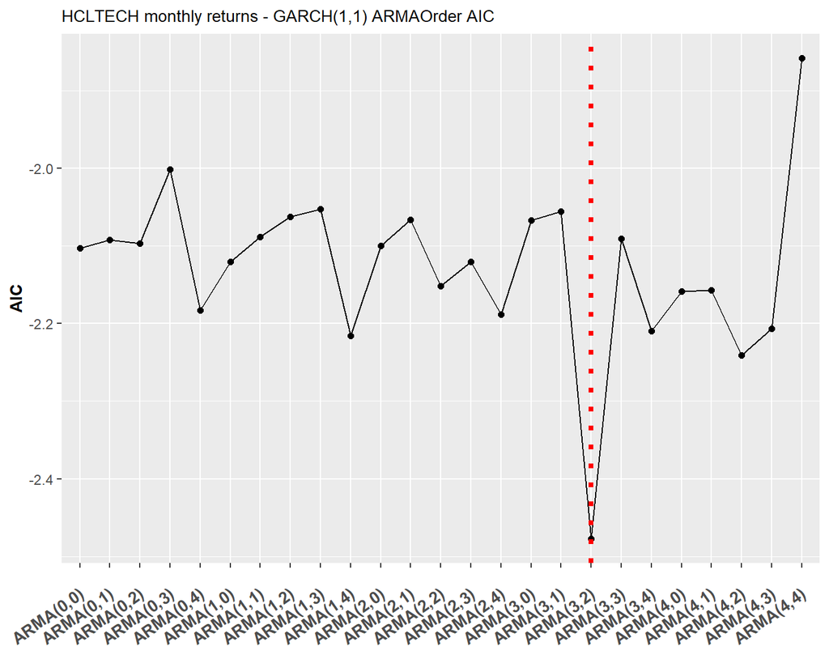

##### The best GARCH model for HCLTECH **monthly** returns is **SGARCH(1,1),ARMA(3,2)**.

##### **HCLTECH** **monthly** VaR summary:

- HCLTECH monthly VaR is **-0.1454** at **alpha=5%**
- HCLTECH monthly conditional mean is **-0.0014**
- HCLTECH monthly conditional sd is **0.0876**

#### Comparisons & Conclusion

##### The company wise VaR, conditional mean and sd looks like this:

Wipro Diagnostic Measures

|  | VaR | Conditional_Mean | Conditional_Sd | VaR_pct |
| --- | --- | --- | --- | --- |
| 1day | -0.0267077 | -0.0002470 | 0.0160870 | -2.67 |
| 1week | -0.1874398 | -0.0011752 | 0.1132408 | -18.74 |
| 1month | -0.3105917 | -0.0051684 | 0.1856842 | -31.06 |

<sup>1</sup> VaR_pct = VaR*100  
<sup>2</sup> Conditional Mean is derived from best ARMA model  
<sup>3</sup> Conditional sd is derived from SGARCH-ARMA model

TCS Diagnostic Measures

|  | VaR | Conditional_Mean | Conditional_Sd | VaR_pct |
| --- | --- | --- | --- | --- |
| 1day | -0.0243308 | 0.0002090 | 0.0149191 | -2.43 |
| 1week | -0.0758544 | 0.0004705 | 0.0464023 | -7.59 |
| 1month | -0.0437718 | 0.0030180 | 0.0284462 | -4.38 |

<sup>1</sup> VaR_pct = VaR*100  
<sup>2</sup> Conditional Mean is derived from best ARMA model  
<sup>3</sup> Conditional sd is derived from SGARCH-ARMA model

HCLTECH Diagnostic Measures

|  | VaR | Conditional_Mean | Conditional_Sd | VaR_pct |
| --- | --- | --- | --- | --- |
| 1day | -0.0310229 | 0.0001459 | 0.0189493 | -3.10 |
| 1week | -0.0719695 | 0.0006941 | 0.0441763 | -7.20 |
| 1month | -0.1454304 | -0.0014170 | 0.0875539 | -14.54 |

<sup>1</sup> VaR_pct = VaR*100  
<sup>2</sup> Conditional Mean is derived from best ARMA model  
<sup>3</sup> Conditional sd is derived from SGARCH-ARMA model

##### The company wise ratios looks like this:

Comparison of Ratios

|  | WIPRO | TCS | HCLTECH |
| --- | --- | --- | --- |
| Week-Day | 7 | 3 | 2 |
| Month-Week | 2 | 1 | 2 |
| Month-Day | 12 | 2 | 5 |

<sup>1</sup> Week-Day = VaR 1 week divided by VaR 1 day  
<sup>2</sup> Month-Week = VaR 1 month divided by VaR 1 week  
<sup>3</sup> Month-Day = VaR 1 month divided by VaR 1 day

###### Declaration:-

*The analyst has taken help from recorded video lectures and reading materials provided by Professor Vineet Virmani. The analyst has sought references from cran and R open documentations specific to package tutorials to get specific programming ideas. However, the analyst has not adopted any unfair means or used any readymade GitHub repositories without prior permission to replicate someone else’s work in this project. Any suspicion from the reviewer can be further clarified via discussions or emails*.

Thank You